# Homework Chapter 1

### Part b

```r
#compute difference observed in sample
diff_sample <- as.numeric(stats[1,2] - stats[2,2])
diff_sample
```

```
[1] 2.432208
```

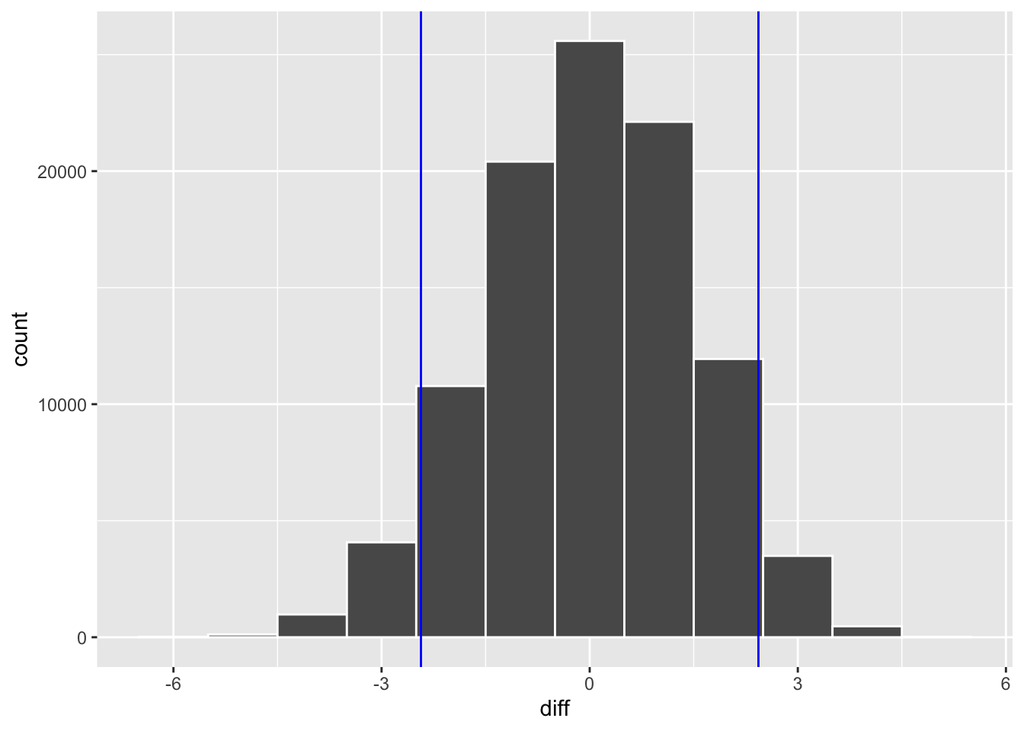

```r
n_no <- stats[1,4] %>% as.numeric()
n <- dim(birdnest)[1]

diff <- c(1e5)
for(i in 1:100000){
  allocation <- sample(birdnest$length,
                       size = n)
  mean_no <- mean(allocation[1:n_no], na.rm = TRUE)
  mean_yes <- mean(allocation[(n_no + 1):n],
                   na.rm = TRUE)
  diff[i] <- mean_no - mean_yes
}


#plot histogram of differences in means (no - yes)
#add vertical line at observed difference
sims <- data.frame(diff = diff)
ggplot(sims, aes(x = diff)) +
  geom_histogram(color = "white",
                 binwidth = 1) +
  geom_vline(xintercept = diff_sample,
             color = "blue") +
  geom_vline(xintercept = -diff_sample,
             color = "blue")
```

```r
#find the two-sided empirical p-value
p_value2 <- sum(diff > abs(diff_sample) |
                  diff < -abs(diff_sample))/100000
p_value2
```

```
[1] 0.10166
```

> Here we are testing the hypotheses *H*<sub>0</sub> : *μ*<sub>*o**p**e**n***</sub> *−* μcl**o**s**e**d = 0 vs. *H*<sub>0</sub> : *μ*<sub>*o**p**e**n***</sub> *−* μcl**o**s**e**d ≠ 0. We obtain an empirical p-value of 0.10166, which is greater than *α* = 0.05, so we fail to reject *H*<sub>0</sub>. That is, there is not sufficient evidence to claim that bodylength differs by type of nest built. There was no random sampling or random allocation used here since it is based on evolutionary data, so even if the finding was significant it could not be used to infer a causal relationship between length and nest type. Other confounding variables could be affecting what type of nest the birds create.

## E.14

### Part a

```r
twins <- read_csv("./data/C1 Twins.csv") %>%
  clean_names()

glimpse(twins)
```

```
Rows: 15
Columns: 4
$ pair_number <dbl> 1, 2, 3, 4, 5, 6, 7, 8, 9, 10, 11, 12, 13, 14, 15
$ unaffected  <dbl> 1.94, 1.44, 1.56, 1.58, 2.06, 1.66, 1.75, 1.77, 1.78, 1.92…
$ affected    <dbl> 1.27, 1.63, 1.47, 1.39, 1.93, 1.26, 1.71, 1.67, 1.28, 1.85…
$ difference  <dbl> 0.67, -0.19, 0.09, 0.19, 0.13, 0.40, 0.04, 0.10, 0.50, 0.0…
```

> The data should be analyzed as matched pairs because each pair of twins is genetically identical and are therefore not independent.

### Part b

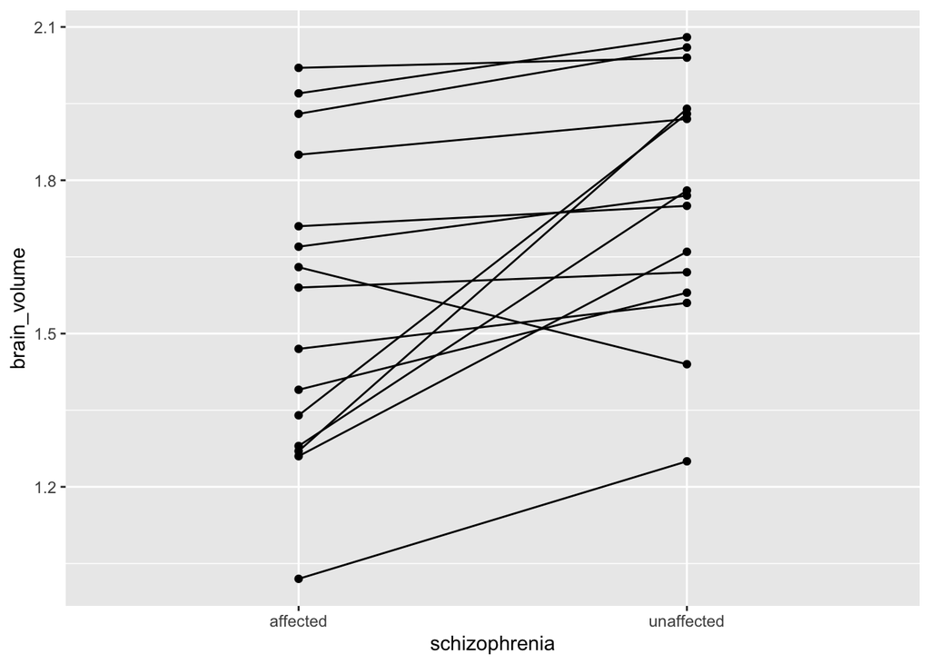

```r
twins_longer <- twins %>%
  pivot_longer(cols = 2:3, names_to = "schizophrenia",
               values_to = "brain_volume")

ggplot(twins_longer, aes(x = schizophrenia,
                         y = brain_volume,
                         group = pair_number)) +
  geom_point() +
  geom_line()
```

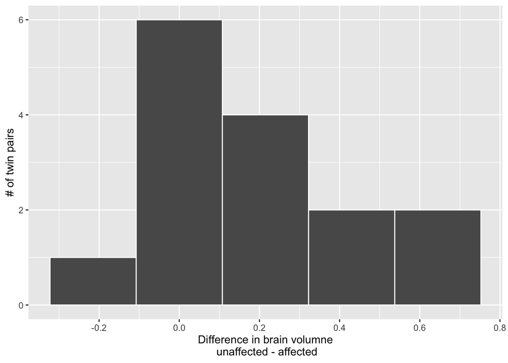

```r
ggplot(twins, aes(x = difference)) +
  geom_histogram(color = "white", bins = 5) +
  labs(x = "Difference in brain volumne\n unaffected - affected",
       y = "# of twin pairs")
```

```r
diff_sample <- twins %>%
  summarize(mean_diff = mean(difference)) %>%
  pull(mean_diff)
diff_sample
```

```
[1] 0.1986667
```

> The first graph indicates that in most twin pairs, the unaffected twin has a higher brain volume (positive slope between the pairs). The second graph shows that the difference in brain volume (unaffected - affected) tends to be positive for most pairs, again indicating the unaffected twin has a higher brain volumne. The average difference is 0.1987 in this sample of twins.

### Part c

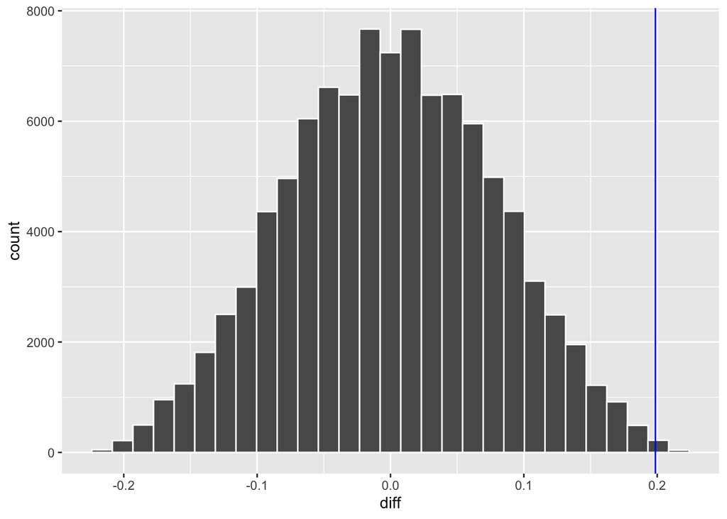

```r
set.seed(437)
twins <- twins %>%
  mutate(rand_01 = rbinom(dim(twins)[1],
                          size = 1, prob = 0.5),
         rand = if_else(rand_01 == 0, -1, 1),
         diff_rand = rand*difference)

n <- dim(twins)[1]
diff <- c(1e5)
for(i in 1:100000){
  #simulate 0-1 coin flip for each twin pair
  allocation <- rbinom(n,
                       size = 1, prob = 0.5)
  #convert 0s to -1s
  allocation2 <- if_else(allocation == 0, -1, 1)
  #multiply differences by random 1s and -1s
  #to mimic the process of randomizing the order of subtraction
  diff_rand <- twins$difference*allocation2
  diff[i] <- mean(diff_rand)
}

sims <- data.frame(diff = diff)
ggplot(sims, aes(x = diff)) +
  geom_histogram(color = "white") +
  geom_vline(xintercept = diff_sample,
             color = "blue")
```

```r
p_value <- sum(diff > abs(diff_sample))/100000
p_value
```

```
[1] 0.0015
```

> The resulting p-value is 0.0015, which is smaller than *α* = 0.05. Therefore, we have sufficient evidence to reject *H*<sub>0</sub>. That is, the brain volume of the twin unaffected by schizophrenia is larger than the brain volume of the affected twin, and the difference is statistically significant.

## Reflection prompts

*Respond to each of the following after you have completed all exercises in this assignment*

*(RP1): What were the main concepts covered in this assignment?*

*(RP2): What’s one thing you understand better after completing these exercises?*

*(RP3): What exercise(s) gave you the most trouble? What was difficult about them/where did you get stuck?*